# 부산시 구별 cctv와 범죄 수의 상관 관계에 대한 분석

Minsoo Joo

2024-12-01

# 부산시 각 구별 CCTV 개수와 범죄 발생간의 상관관계에 대한 분석

### 1. 필요한 패키지 로드

```r
knitr::opts_chunk$set(echo = TRUE)
install.packages("ggmap", repos="http://cran.us.r-project.org")
```

```r
install.packages("ggplot2", repos="http://cran.us.r-project.org")
install.packages("raster", repos="http://cran.us.r-project.org")
install.packages("sf", repos="http://cran.us.r-project.org")
```

```
## Error in download.file(url, destfile, method, mode = "wb", ...) :
##   download from 'http://cran.us.r-project.org/bin/macosx/big-sur-arm64/contrib/4.4/sf_1.0-19.tgz' failed
```

```r
install.packages("tidyverse", repos="http://cran.us.r-project.org")
```

```r
install.packages("maps", repos="http://cran.us.r-project.org")
install.packages("tidyr", repos="http://cran.us.r-project.org")
install.packages("geodata", repos="http://cran.us.r-project.org")
install.packages("rgdal", repos="http://cran.us.r-project.org")
install.packages("mapproj", repos="http://cran.us.r-project.org")
library(tidyverse)
library(tidyr)
library(ggplot2)
library(maps)
library(sf)
library(sp)
library(ggmap)
library(raster)
library(geodata)
library(mapproj)
```

### 2. 데이터 불러오기

```r
# 데이터 로드 환경 정리.
rm(list = ls())
# 부산의 구별 cctv 개수 데이터, 한국어 데이터이기에 인코딩 EUC-KR 사용.
busan_cctv <- read_csv("~/Desktop/R_project/Cctv_info.csv", locale = locale(encoding = "EUC-KR"))
# 한국 지도 데이터 가져오기.
korea <- gadm("GADM", country="kor", level=1)
korea_map <- as.data.frame(korea)
# 한국 시군구별 지도 데이터 가져오기.
korea_map_Gu <- st_read("~/Desktop/R_project/sig.shp")
# 부산 구별 범죄 발생 현황 데이터 가져오기.
crime_num <- read_csv("~/Desktop/R_project/Crime_num.csv", locale = locale(encoding = "EUC-KR"))
```

### 3. 데이터 전처리

```r
# 1. 부산 CCTV 데이터 확인.
head(busan_cctv)
```

```
## # A tibble: 6 × 3
##   cctv_name                                     cctv_coord            cctv_group
##   <chr>                                         <chr>                 <chr>
## 1 (10차)강서-10-232-1죽동동381가락송산마을(고1) 10.1.11.186:0:0:0:0:… 강서-10차
## 2 (10차)강서-10-232-2죽동동381가락송산마을(고2) 10.1.11.186:0:0:0:0:… 강서-10차
## 3 (10차)강서-10-233-1대저2동3147근린공원(고1)   10.1.11.186:0:0:0:0:… 강서-10차
## 4 (10차)강서-10-233-2대저2동3147근린공원(고2)   10.1.11.186:0:0:0:0:… 강서-10차
## 5 (10차)강서-10-235-2대저2동2041-40덕두시장     10.1.11.186:0:0:0:0:… 강서-10차
## 6 (10차)강서-10-236-1송정동1731녹산공단대창스틸 10.1.11.186:0:0:0:0:… 강서-10차
```

```r
# 2. 부산 CCTV 개수를 구별로 세기 위해 cctv_group 변수에 있는 N차 부분 제거 필요. 앞 두글자로 정리.
busan_cctv_gu <- busan_cctv %>% dplyr::select(cctv_name,cctv_coord,cctv_group) %>%
  mutate(Gu = substr(cctv_group, 0, 2))
```

```r
# 3. 부산 CCTV 개수를 구별로 세어 새로운 열 생성.
busan_cctv_gu_num <- busan_cctv_gu %>% count(Gu)
head(busan_cctv_gu_num)
```

```
## # A tibble: 6 × 2
##   Gu        n
##   <chr> <int>
## 1 강서    352
## 2 금정    403
## 3 기장    344
## 4 남구    351
## 5 동구    374
## 6 동래    404
```

```r
# 4. 한국 지도 시별 데이터 변환하기.
## a. 지도 데이터를 fortify 함수 사용하여 spatial 데이터 형태로 변환.
map_sf_df <- fortify(korea_map_Gu)
map_sf_df |> head(10)
```

```
## Simple feature collection with 10 features and 3 fields
## Geometry type: MULTIPOLYGON
## Dimension:     XY
## Bounding box:  xmin: 950928.8 ymin: 1945376 xmax: 966325.5 ymax: 1966987
## Projected CRS: PCS_ITRF2000_TM
##    SIG_CD    SIG_ENG_NM               SIG_KOR_NM                       geometry
## 1   11110     Jongno-gu        \xc1\xbe\xb7α\xb8 MULTIPOLYGON (((956615.5 19...
## 2   11140       Jung-gu                 \xc1߱\xb8 MULTIPOLYGON (((957890.4 19...
## 3   11170    Yongsan-gu           \xbf\xeb\xbb걸 MULTIPOLYGON (((953115.8 19...
## 4   11200  Seongdong-gu \xbc\xba\xb5\xbf\xb1\xb8 MULTIPOLYGON (((959681.1 19...
## 5   11215   Gwangjin-gu \xb1\xa4\xc1\xf8\xb1\xb8 MULTIPOLYGON (((964825.1 19...
## 6   11230 Dongdaemun-gu   \xb5\xbf\xb4빮\xb1\xb8 MULTIPOLYGON (((962141.9 19...
## 7   11260   Jungnang-gu        \xc1߶\xfb\xb1\xb8 MULTIPOLYGON (((965698.5 19...
## 8   11290   Seongbuk-gu        \xbc\xba\xbaϱ\xb8 MULTIPOLYGON (((956787.3 19...
## 9   11305    Gangbuk-gu        \xb0\xad\xbaϱ\xb8 MULTIPOLYGON (((956316.8 19...
## 10  11320     Dobong-gu \xb5\xb5\xba\xc0\xb1\xb8 MULTIPOLYGON (((957223.8 19...
```

```r
## b. spatial 데이터로 변환된 지도 데이터를 dataframe 형태로 변환.
map_sf_df$SIG_KOR_NM <- iconv(map_sf_df$SIG_KOR_NM, from="CP949", to="UTF-8", sub= NA, mark=TRUE, toRaw=FALSE)
map_sf_df |> head(10)
```

```
## Simple feature collection with 10 features and 3 fields
## Geometry type: MULTIPOLYGON
## Dimension:     XY
## Bounding box:  xmin: 950928.8 ymin: 1945376 xmax: 966325.5 ymax: 1966987
## Projected CRS: PCS_ITRF2000_TM
##    SIG_CD    SIG_ENG_NM SIG_KOR_NM                       geometry
## 1   11110     Jongno-gu     종로구 MULTIPOLYGON (((956615.5 19...
## 2   11140       Jung-gu       중구 MULTIPOLYGON (((957890.4 19...
## 3   11170    Yongsan-gu     용산구 MULTIPOLYGON (((953115.8 19...
## 4   11200  Seongdong-gu     성동구 MULTIPOLYGON (((959681.1 19...
## 5   11215   Gwangjin-gu     광진구 MULTIPOLYGON (((964825.1 19...
## 6   11230 Dongdaemun-gu   동대문구 MULTIPOLYGON (((962141.9 19...
## 7   11260   Jungnang-gu     중랑구 MULTIPOLYGON (((965698.5 19...
## 8   11290   Seongbuk-gu     성북구 MULTIPOLYGON (((956787.3 19...
## 9   11305    Gangbuk-gu     강북구 MULTIPOLYGON (((956316.8 19...
## 10  11320     Dobong-gu     도봉구 MULTIPOLYGON (((957223.8 19...
```

```r
# 5. 한국 지도 시군구별 데이터 변환하기.
## a. 지도 데이터를 fortify 함수 사용하여 spatial 데이터 형태로 변환.
map_sf_df <- fortify(korea_map_Gu)
map_sf_df |> head(10)
```

```
## Simple feature collection with 10 features and 3 fields
## Geometry type: MULTIPOLYGON
## Dimension:     XY
## Bounding box:  xmin: 950928.8 ymin: 1945376 xmax: 966325.5 ymax: 1966987
## Projected CRS: PCS_ITRF2000_TM
##    SIG_CD    SIG_ENG_NM               SIG_KOR_NM                       geometry
## 1   11110     Jongno-gu        \xc1\xbe\xb7α\xb8 MULTIPOLYGON (((956615.5 19...
## 2   11140       Jung-gu                 \xc1߱\xb8 MULTIPOLYGON (((957890.4 19...
## 3   11170    Yongsan-gu           \xbf\xeb\xbb걸 MULTIPOLYGON (((953115.8 19...
## 4   11200  Seongdong-gu \xbc\xba\xb5\xbf\xb1\xb8 MULTIPOLYGON (((959681.1 19...
## 5   11215   Gwangjin-gu \xb1\xa4\xc1\xf8\xb1\xb8 MULTIPOLYGON (((964825.1 19...
## 6   11230 Dongdaemun-gu   \xb5\xbf\xb4빮\xb1\xb8 MULTIPOLYGON (((962141.9 19...
## 7   11260   Jungnang-gu        \xc1߶\xfb\xb1\xb8 MULTIPOLYGON (((965698.5 19...
## 8   11290   Seongbuk-gu        \xbc\xba\xbaϱ\xb8 MULTIPOLYGON (((956787.3 19...
## 9   11305    Gangbuk-gu        \xb0\xad\xbaϱ\xb8 MULTIPOLYGON (((956316.8 19...
## 10  11320     Dobong-gu \xb5\xb5\xba\xc0\xb1\xb8 MULTIPOLYGON (((957223.8 19...
```

```r
## b. spatial 데이터로 변환된 지도 데이터를 dataframe 형태로 변환.
map_sf_df$SIG_KOR_NM <- iconv(map_sf_df$SIG_KOR_NM, from="CP949", to="UTF-8", sub= NA, mark=TRUE, toRaw=FALSE)
map_sf_df |> head(10)
```

```
## Simple feature collection with 10 features and 3 fields
## Geometry type: MULTIPOLYGON
## Dimension:     XY
## Bounding box:  xmin: 950928.8 ymin: 1945376 xmax: 966325.5 ymax: 1966987
## Projected CRS: PCS_ITRF2000_TM
##    SIG_CD    SIG_ENG_NM SIG_KOR_NM                       geometry
## 1   11110     Jongno-gu     종로구 MULTIPOLYGON (((956615.5 19...
## 2   11140       Jung-gu       중구 MULTIPOLYGON (((957890.4 19...
## 3   11170    Yongsan-gu     용산구 MULTIPOLYGON (((953115.8 19...
## 4   11200  Seongdong-gu     성동구 MULTIPOLYGON (((959681.1 19...
## 5   11215   Gwangjin-gu     광진구 MULTIPOLYGON (((964825.1 19...
## 6   11230 Dongdaemun-gu   동대문구 MULTIPOLYGON (((962141.9 19...
## 7   11260   Jungnang-gu     중랑구 MULTIPOLYGON (((965698.5 19...
## 8   11290   Seongbuk-gu     성북구 MULTIPOLYGON (((956787.3 19...
## 9   11305    Gangbuk-gu     강북구 MULTIPOLYGON (((956316.8 19...
## 10  11320     Dobong-gu     도봉구 MULTIPOLYGON (((957223.8 19...
```

### 4. 한국 지도 그리기

```r
# 1. 좌표 확인.
coords <- st_coordinates(korea_map_Gu)
head(coords)
```

```
##             X       Y L1 L2 L3
## [1,] 956615.5 1953567  1  1  1
## [2,] 956621.6 1953565  1  1  1
## [3,] 956626.2 1953564  1  1  1
## [4,] 956638.8 1953562  1  1  1
## [5,] 956659.1 1953559  1  1  1
## [6,] 956661.5 1953558  1  1  1
```

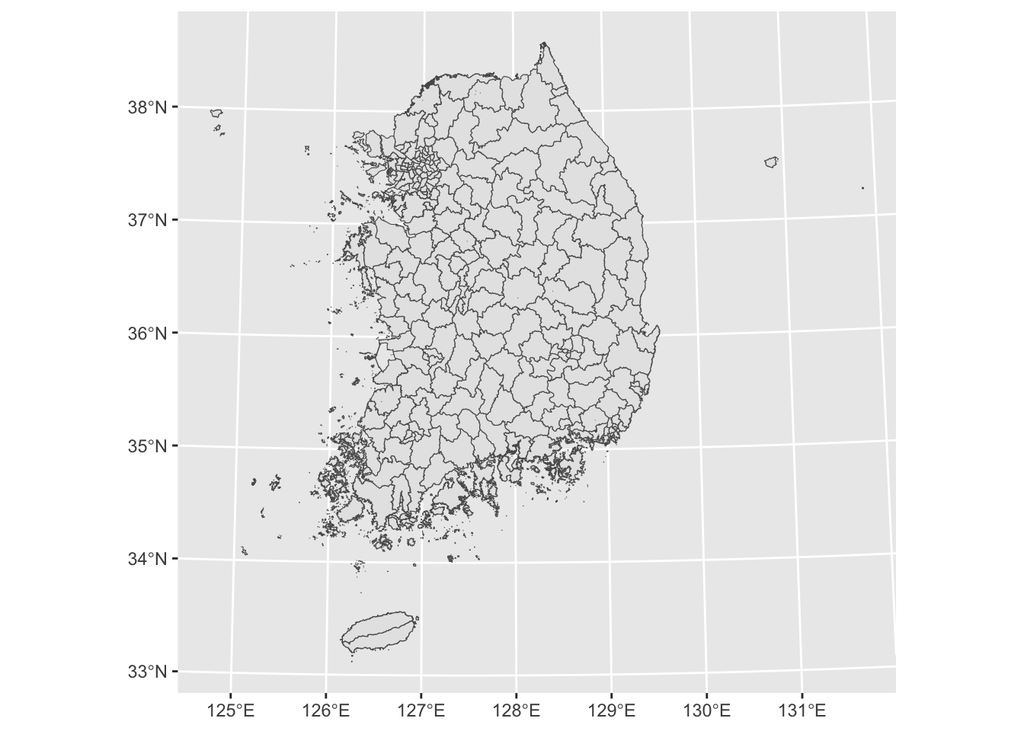

```r
# 2. 지도 그리기.
korea_map_Gu |> ggplot() + geom_sf()
```

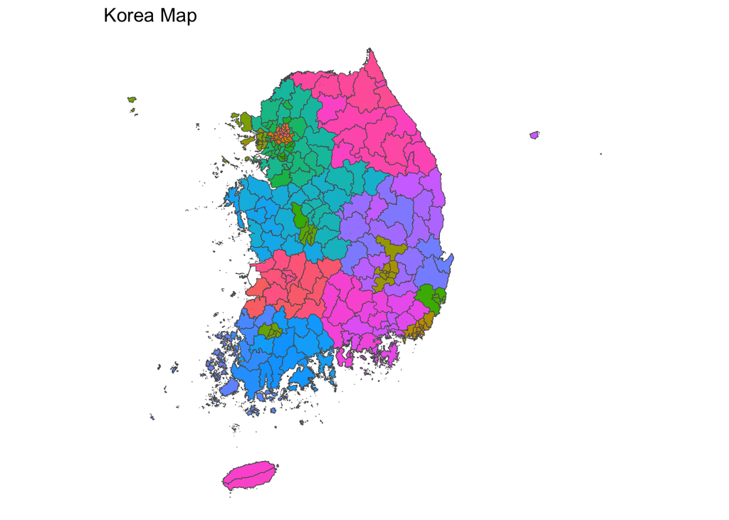

```r
korea_map_Gu |> ggplot() + geom_sf(aes(fill = SIG_CD), show.legend=FALSE) + ggtitle("Korea Map") + theme_void()
```

```r
# 3. 부산 지도 그리기.
## a. 부산 데이터만 뽑기.
map_sf_busan <- korea_map_Gu |> filter(str_detect(SIG_CD, "^26"))
## b. 부산 데이터 코드 확인 후 지도 그리기.
unique(map_sf_busan$SIG_CD)
```

```
##  [1] "26110" "26140" "26170" "26200" "26230" "26260" "26290" "26320" "26350"
## [10] "26380" "26410" "26440" "26470" "26500" "26530" "26710"
```

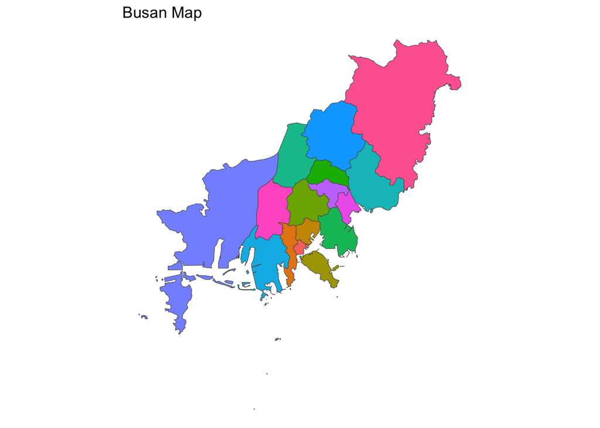

```r
map_sf_busan |> ggplot() + geom_sf(aes(fill = SIG_CD), show.legend = FALSE) + ggtitle("Busan Map") + theme_void()
```

### 5. 부산 지도 데이터와 CCTV 수 범죄 수 인구 수 데이터 합치기

```r
# 1. CCTV 수 데이터 병합.
map_sf_busan[,"cctv_num"] <- c(337,348,374,381,395,404,351,403,418,431,403,352,377,365,422,344)
# 2. 범죄 수 데이터 병합.
crime_num <- crime_num %>% dplyr::select(Station,murder,robbery,sex,thief,violation) %>%
  mutate(total = murder+robbery+sex+thief+violation)
map_sf_busan[, "crime_num"] <- c(1402,1253,1353,1079,5616,2675,3029,2070,3128,2323,1796,1153,2668,NA,2063,1472)
# 3. 인구 수 데이터 병합.
map_sf_busan[, "population"] <- c(38487,103694,87460,106233,360881,269350,255107,272315,378753,296253,214168,141783,210999,173944,202062,177912)
head(map_sf_busan)
```

```
## Simple feature collection with 6 features and 6 fields
## Geometry type: MULTIPOLYGON
## Dimension:     XY
## Bounding box:  xmin: 1136286 ymin: 1672457 xmax: 1147142 ymax: 1693462
## Projected CRS: PCS_ITRF2000_TM
##   SIG_CD  SIG_ENG_NM                SIG_KOR_NM                       geometry
## 1  26110     Jung-gu                  \xc1߱\xb8 MULTIPOLYGON (((1140570 168...
## 2  26140      Seo-gu          \xbc\xad\xb1\xb8 MULTIPOLYGON (((1138209 167...
## 3  26170     Dong-gu          \xb5\xbf\xb1\xb8 MULTIPOLYGON (((1141114 168...
## 4  26200  Yeongdo-gu  \xbf\xb5\xb5\xb5\xb1\xb8 MULTIPOLYGON (((1145322 167...
## 5  26230 Busanjin-gu \xbaλ\xea\xc1\xf8\xb1\xb8 MULTIPOLYGON (((1140192 169...
## 6  26260  Dongnae-gu  \xb5\xbf\xb7\xa1\xb1\xb8 MULTIPOLYGON (((1143702 169...
##   cctv_num crime_num population
## 1      337      1402      38487
## 2      348      1253     103694
## 3      374      1353      87460
## 4      381      1079     106233
## 5      395      5616     360881
## 6      404      2675     269350
```

### 6. 부산시 구별 CCTV 수, 범죄 수, 인구 수 지도로 보기

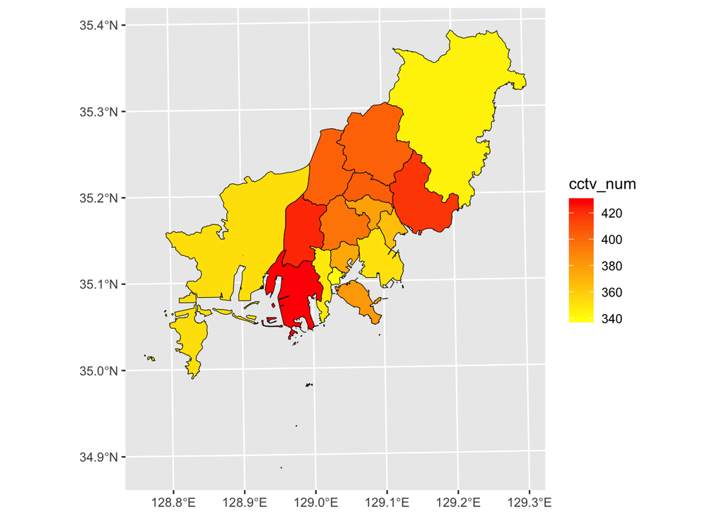

```r
map_sf_busan |> ggplot() + geom_sf(aes(fill = cctv_num), color="black") +
  scale_fill_continuous(low="yellow", high="red", labels=scales::comma)
```

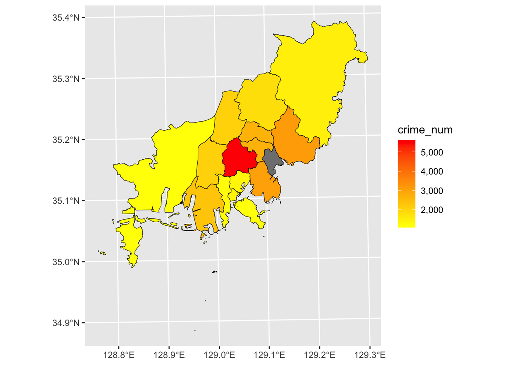

```r
map_sf_busan |> ggplot() + geom_sf(aes(fill = crime_num), color="black") +
  scale_fill_continuous(low="yellow", high="red", labels=scales::comma)
```

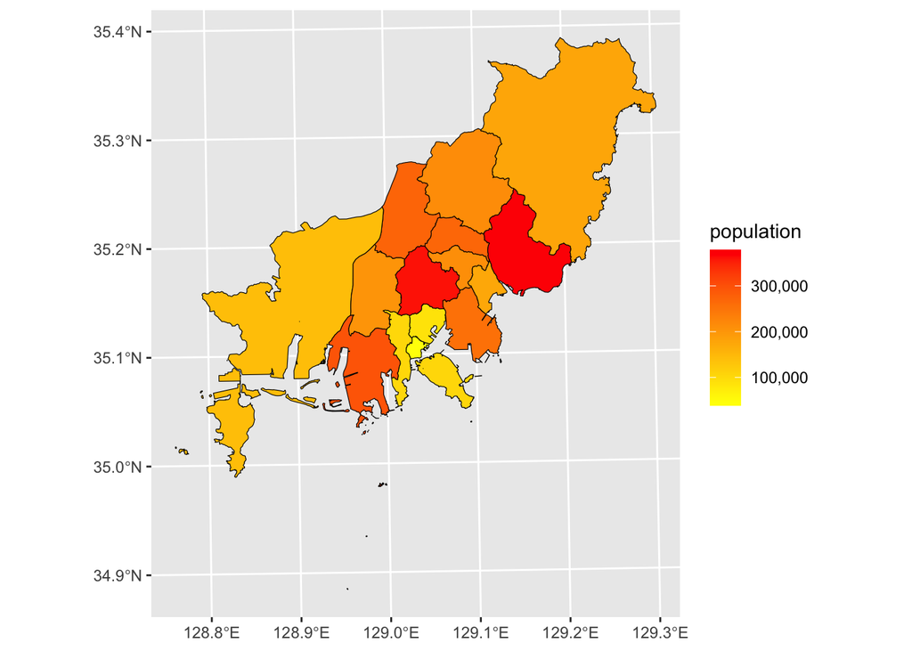

```r
map_sf_busan |> ggplot() + geom_sf(aes(fill = population), color="black") +
  scale_fill_continuous(low="yellow", high="red", labels=scales::comma)
```

### 7. 중간 분석

#### 위의 CCTV 수, 범죄 수, 인구 수 데이터들을 지도로 표현하여 보았을 때 그 정도를 나타내는 색 (빨간색이 높은 수치)의 분포가 비슷하다고 판단됨. 기존에 예측했던 분석 결과는 CCTV 수가 적으면 범죄 수가 많을 것으로 예상했음. 예측대로라면 CCTV 수 지도의 노란색이 강한 구의 경우 범죄 수 지도에서 빨간색이 강해야 하며 CCTV 수 지도의 빨간색이 강한 구의 경우는 범죄 수 지도에서 노란색이 강해야 함. 하지만 지도에서 보여지는 결과는 상이하며 범죄 수 보다는 인구 대비 범죄율을 기준으로 분석을 이어 나가야할 것으로 판단됨.

### 8. 범죄율 산정하기

```r
# 1. 인구 수 대비 범죄율 산정은 범죄수/인구수 * 100으로 산정됨.
map_sf_busan <- map_sf_busan %>% dplyr::select(SIG_CD, SIG_ENG_NM, SIG_KOR_NM, geometry, cctv_num, crime_num, population) %>%
  mutate(crime_per = (crime_num/population)*100)
```

### 9. CCTV 수와 범죄율간의 상관관계 분석하기

```r
# 1. 수영구 데이터가 없었으므로 해당 데이터를 제외하고 두 변수간의 상관관계 분석
map_sf_busan_naomit <- na.omit(map_sf_busan)
cor(map_sf_busan_naomit$cctv_num, map_sf_busan_naomit$crime_per)
```

```
## [1] -0.4649778
```

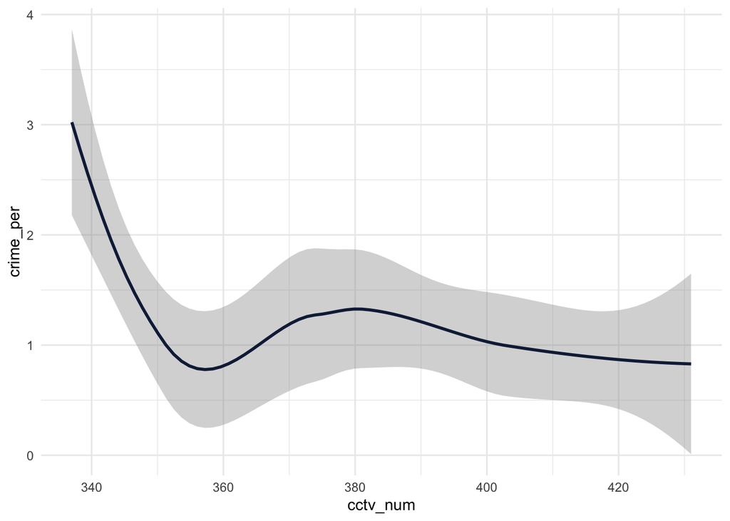

```r
ggplot(map_sf_busan_naomit) +
  aes(x = cctv_num, y = crime_per) +
  geom_smooth(se = TRUE, colour = "#112446") +
  theme_minimal()
```